# Project 1: Deadlock Meta Analysis

Tiana Nguyen

2026-11-01

## Background

### The game

Deadlock is a third-person hero shooter and MOBA (multiplayer online battle arena) made by Valve, the company behind Steam, Half-Life, Counter-Strike, and Portal. Two teams of six players each pick a hero, and the teams fight to destroy the other side’s base while collecting “souls,” the in-game currency used to buy items and grow stronger over a match. Each hero has its own abilities, so which hero you pick matters a great deal, and a community-wide picture of which heroes are being picked, banned, and winning is called the **meta**. Deadlock is still in an invite-only closed beta, which means Valve changes it constantly. The data in this project was collected right after a major patch added **six new heroes** (Rat King, Baba, Solomon, Deadman Danny, Violet, and Nurse Harrow), so it covers a rare moment in which the meta had to be rebuilt almost from scratch.

### Why I care

I am currently obsessed with this game, and I wanted a project where I could look at it the way a data analyst would instead of the way a player does. As a player I have strong opinions: “this hero is overpowered,” “nobody can play this hero well,” “everybody picks X.” This project lets me test those opinions against real numbers from tens of thousands of matches. It is also timely. When six heroes arrive in a single month, players, and Valve’s balance team, want to know quickly whether any of them are broken, whether they are too hard or too easy to learn, and how they changed the rest of the roster’s popularity.

### The data

All of the data comes from the community-run **Deadlock API** (api.deadlock-api.com), which publishes aggregated match statistics from active players. I requested the data on October 26, 2026, after all six new heroes were released. It covers **September 26 to October 26, 2026**, all **44 heroes**, and all **11 ranks** (from Initiate up to Eternus, each with sub-ranks), and totals about **6.9 million hero-matches**. The data came as two tables:

- **Hero stats** by hero, rank, and day: wins, losses, matches, and the totals of kills, deaths, assists, net worth (souls), last hits, denies, player damage dealt and taken, boss damage, shots hit and missed, and permanent buffs.
- **Hero bans** by hero, rank, and day: the number of times each hero was banned.

The variables most important to my analysis are `hero_name`, `rank_tier` / `rank_name` (skill level), `date`, `wins` and `matches` (which give win rate and pick rate), `bans`, and the per-match stat totals such as deaths, net worth, denies, and shot accuracy.

### Research questions

1. **Meta:** Which heroes are the most picked, most banned, and most successful, and are those the same heroes? Does popularity or banning reflect how strong a hero really is?
2. **Skill expression:** Which heroes get *better* as the skill level rises (they reward mastery), and which fade at higher ranks?
3. **New heroes:** Do the six new heroes start weak and improve as players learn them, and is any of them dominant?
4. **How play changes with rank:** How do things like deaths, accuracy, souls, and denies change from Initiate to Eternus, and who dies the most?

### What I hope to learn

I hope to find out whether the community’s intuitions about the meta hold up in the data, which heroes are best for a player who wants to climb, and what separates high-rank play from low-rank play. For a player like me the practical payoff is picking heroes that fit my rank and my learning goals. For a data analyst, the payoff is practice at turning a raw API dump into a story.

## Data Wrangling and Cleaning

The API data arrives as separate tables, so most of the wrangling was getting the two tables into one consistent structure and turning raw counts into rates I can compare across heroes. Each step below was done for a specific reason.

```r
stats <- read_csv("hero_stats_by_rank_subrank_and_date.csv")
bans  <- read_csv("hero_bans_by_rank_subrank_and_date.csv")

combined <- stats %>%
  select(hero_id, hero_name, bucket, badge, rank_tier, rank_name, subrank,
         wins, losses, matches, matches_per_bucket) %>%
  full_join(select(bans, hero_id, bucket, badge, bans),
            by = c("hero_id", "bucket", "badge")) %>%
  mutate(bans = replace_na(bans, 0),
         across(c(wins, losses, matches), ~ replace_na(.x, 0)),
         date = as_date(as_datetime(bucket))) %>%
  group_by(badge, date) %>%
  mutate(matches_per_bucket = max(matches_per_bucket, na.rm = TRUE),
         total_bans = sum(bans),
         ban_share = if_else(total_bans > 0, bans / total_bans, NA_real_),
         pick_rate = matches / matches_per_bucket,
         win_rate = if_else(matches > 0, wins / matches, NA_real_),
         bans_per_100_games = 100 * bans / (matches_per_bucket / 12)) %>%
  ungroup()
```

**What I did and why:**

- **Selected only relevant columns.** The stats file has more than 30 columns. For the meta analysis I kept identifiers, ranks, and win/loss/match counts; the full set of per-match stats is used later for the rank analysis.
- **Joined the stats and bans tables.** Bans live in a separate table, so I used a full join on hero, day (`bucket`), and rank (`badge`). A full join keeps rows that exist in only one table. About 99 ban rows (0.03% of all bans) had no matching stats row, so they carry no hero name and are dropped when I summarize by hero. That is too small to matter, but I checked it rather than assuming.
- **Handled missing values.** After the join, hero-days with no bans have `NA`, which really means zero bans, so I replaced those with 0. Likewise, missing wins, losses, and matches became 0.
- **Changed variable types.** The API gives time as a Unix timestamp (`bucket`, seconds since 1970), which is unreadable. I converted it to a real date so I can plot and filter by day.
- **Created new variables.** Raw counts cannot be compared fairly across heroes and ranks, because some ranks have far more games than others. I created **win rate** (wins divided by matches), **pick rate** (a hero’s matches divided by all matches, so the numbers sum to 1 across heroes), **ban share** (a hero’s bans divided by all bans), and **bans per 100 games**. Because each game has 12 players, I divided matches by 12 to estimate the number of games.
- **Grouped and summarized.** I rolled the day-by-day, rank-by-rank rows up to one row per hero (for the overall meta plots) and one row per hero per rank (for the rank analysis).
- **Filtered unreliable observations.** About 35% of the individual hero-rank-day rows come from fewer than 50 matches, which makes their win rates very noisy (one win or loss swings the rate by 2 percentage points). So I never judge a hero from one day. I always aggregate across days first, and for the rank analysis I only keep hero-rank cells with at least **200 matches**.

```r
heroes_raw <- fromJSON("https://api.deadlock-api.com/v1/assets/heroes", flatten = TRUE)
img_cols <- names(heroes_raw)[str_detect(names(heroes_raw), "^images\\.")]

preferred <- c("images.icon_hero_card", "images.icon_image_small",
               "images.selection_image", "images.minimap_image")
img_col <- c(intersect(preferred, img_cols), img_cols)[1]

dir.create("hero_icons", showWarnings = FALSE)

icons <- heroes_raw %>%
  transmute(hero_id = id, icon_url = .data[[img_col]]) %>%
  filter(!is.na(icon_url)) %>%
  mutate(icon_file = file.path("hero_icons", paste0(hero_id, ".png")))

walk2(icons$icon_url, icons$icon_file, function(u, f) {
  if (!file.exists(f)) {
    tmp <- tempfile()
    try({
      download.file(u, tmp, mode = "wb", quiet = TRUE)
      image_read(tmp) %>% image_scale("96x96") %>% image_write(f, format = "png")
    }, silent = TRUE)
  }
})
icons <- icons %>% filter(file.exists(icon_file))
```

The hero icons come from a third API endpoint. I downloaded each icon and shrunk it to 96x96 pixels so the plots can show every hero’s face instead of a plain dot. This makes the scatter plots much easier to read than labels would.

**Two problems I found and how I handled them:**

1. **The six new heroes have no ban records.** Rat King, Baba, Solomon, Deadman Danny, Violet, and Nurse Harrow do not appear in the bans table at all. If I had filled those with 0 bans, the ban plots would claim the new heroes are never banned, which is not supported by the data. I treat their ban share as *missing* (`NA`) instead, and I leave them off the ban plot.
2. **The new heroes joined the game at different times** (Rat King on October 2, Baba on October 6, Solomon on October 9, Deadman Danny on October 13, Violet on October 16, and Nurse Harrow on October 20), so they had fewer days to collect matches than the other 38 heroes. Their pick rates are not directly comparable to the older heroes, which I keep in mind when I interpret them.

```r
icon_scatter <- function(df, xvar, yvar, xlab, ylab, title, sx = 0.05, sy = 0.075) {
  df <- df %>% filter(!is.na(icon_url), !is.na(.data[[xvar]]), !is.na(.data[[yvar]]))
  x <- df[[xvar]]; y <- df[[yvar]]
  xr <- diff(range(x)); yr <- diff(range(y))

  imgs <- pmap(list(x, y, df$icon_url), function(xx, yy, u) {
    list(source = u, xref = "x", yref = "y", x = xx, y = yy,
         sizex = xr * sx, sizey = yr * sy,
         xanchor = "center", yanchor = "middle", layer = "above")
  })

  hover <- paste0(df$hero_name, "<br>", xlab, ": ", signif(x, 3),
                  "<br>", ylab, ": ", signif(y, 3))

  plot_ly(x = x, y = y, type = "scatter", mode = "markers",
          marker = list(size = 20, opacity = 0.01),
          text = hover, hoverinfo = "text") %>%
    layout(title = title,
           xaxis = list(title = xlab, range = c(min(x) - xr * 0.1, max(x) + xr * 0.1)),
           yaxis = list(title = ylab, range = c(min(y) - yr * 0.1, max(y) + yr * 0.1)),
           images = imgs)
}

ban_heroes <- unique(bans$hero_id)   # heroes that actually have ban records

hero <- combined %>%
  group_by(hero_id, hero_name) %>%
  summarise(matches = sum(matches),
            wins = sum(wins),
            bans = sum(bans), .groups = "drop") %>%
  mutate(win_rate = wins / matches,
         pick_rate = matches / sum(matches),
         ban_share = if_else(hero_id %in% ban_heroes, bans / sum(bans), NA_real_)) %>%
  left_join(icons, by = "hero_id") %>%
  filter(!is.na(hero_name))
```

The `hero` table now has one row per hero with its overall win rate, pick rate, and ban share, and it is the foundation for the meta plots. Next I build a second table with one row per hero per rank, which turns every raw total into a per-match average (for example, total deaths divided by matches), so that ranks with more games do not look artificially higher.

```r
min_matches <- 200   # ignore hero-rank cells with fewer matches than this

rank_levels <- stats %>%
  filter(!is.na(rank_tier)) %>%
  distinct(rank_tier, rank_name) %>%
  arrange(rank_tier) %>%
  pull(rank_name)

hero_rank <- stats %>%
  filter(!is.na(rank_tier), !is.na(hero_name)) %>%
  group_by(hero_id, hero_name, rank_tier, rank_name) %>%
  summarise(across(c(wins, matches, total_kills, total_deaths, total_assists,
                     total_net_worth, total_last_hits, total_denies,
                     total_player_damage, total_player_damage_taken,
                     total_boss_damage, total_shots_hit, total_shots_missed,
                     total_permanent_buffs, permanent_buff_matches),
                   ~ sum(.x, na.rm = TRUE)),
            .groups = "drop") %>%
  filter(matches >= min_matches) %>%
  mutate(rank_name = factor(rank_name, levels = rank_levels),
         win_rate  = wins / matches,
         kills     = total_kills / matches,
         deaths    = total_deaths / matches,
         assists   = total_assists / matches,
         net_worth = total_net_worth / matches,
         last_hits = total_last_hits / matches,
         denies    = total_denies / matches,
         damage_dealt = total_player_damage / matches,
         damage_taken = total_player_damage_taken / matches,
         boss_damage  = total_boss_damage / matches,
         accuracy     = total_shots_hit / (total_shots_hit + total_shots_missed),
         permanent_buffs = if_else(permanent_buff_matches > 0,
                                   total_permanent_buffs / permanent_buff_matches,
                                   NA_real_))
```

## Data Analysis

### Overall Look: The Meta

#### Pick rate

Before a match starts, every player picks one hero, so **pick rate** shows how often the community chooses each hero. A high pick rate can mean a hero is strong, fun, easy to play, or simply new and exciting, and a low win rate with a high pick rate suggests players like the hero more than the results justify.

```r
icon_scatter(hero,
             "pick_rate", "win_rate",
             "Pick rate (share of all picks)",
             "Win rate",
             "Pick rate vs win rate") %>%
  layout(shapes = list(list(type = "line", x0 = 0, x1 = 1, y0 = 0.5, y1 = 0.5,
                            line = list(dash = "dash", color = "grey"))))
```

[interactive chart not shown]

**What this shows.** Each icon is a hero, and the dashed line is a 50% win rate. The most important thing to notice is that **Rat King, one of the six new heroes, sits alone in the top right corner**: it is the single most picked hero (about 5.7% of all picks) *and* has the highest win rate (about 55.8%). Right behind it, Haze is the second most picked hero (4.8%) with a 52.9% win rate. In general, popular heroes tend to win more (the correlation between pick rate and win rate is about 0.46), which makes sense because players drift toward what works, but there are exceptions. Infernus (3.7% picks, 47.8% win rate) and Bebop (3.5% picks, 47.0%) are very popular but win less than half their games. At the bottom of the plot, Mirage (43.2%) and Warden (44.0%) win the least and are also among the least picked.

#### Ban rate

Players can **ban** heroes before the match, which removes them from the game, so a hero’s ban share is a measure of how much the community is afraid of (or annoyed by) it. I show ban share only for the 38 heroes that have ban records.

```r
hero %>%
  filter(hero_id %in% ban_heroes) %>%
  icon_scatter("ban_share", "win_rate",
               "Ban rate (share of all bans)",
               "Win rate",
               "Ban rate vs win rate") %>%
  layout(shapes = list(list(type = "line", x0 = 0, x1 = 1, y0 = 0.5, y1 = 0.5,
                            line = list(dash = "dash", color = "grey"))))
```

[interactive chart not shown]

**What this shows.** Haze is the most banned hero by a clear margin (7.6% of all bans), followed by The Doorman (5.8%), Bebop (5.7%), Celeste (5.6%), and Wraith (5.1%). The surprise is how loosely bans track actual strength: the correlation between ban share and win rate is only about 0.29. **The Doorman is the standout example.** It is the second most banned hero, yet it wins just 46.0% of games and is only picked in about 1.2% of matches. Players are not banning it because it is winning; they are banning it because it is frustrating to play against, or because it is strong in the hands of a few specialists. By contrast, Graves wins 55.1% and Paige wins 55.0%, but they are banned much less than their strength would suggest (Paige: 1.3% of bans).

### Character Skill Expression

Some heroes are easy to pick up, while others take hours to master. If a hero is *hard to master*, its win rate should be low at low ranks and climb at high ranks. I measured this by fitting a straight line to each hero’s win rate across the 11 ranks (weighted by the number of matches), so that the slope is the change in win rate for each step up the ranked ladder.

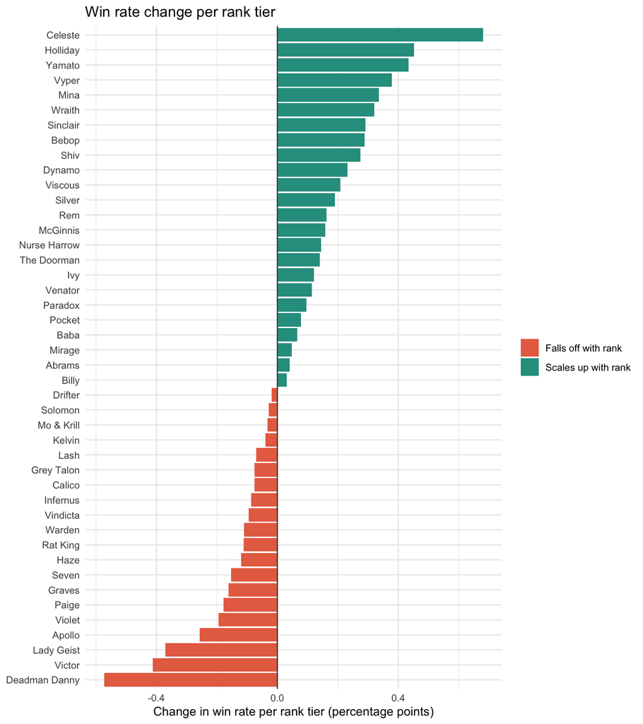

```r
slopes <- hero_rank %>%
  group_by(hero_id, hero_name) %>%
  filter(n() >= 5) %>%
  summarise(slope = unname(coef(lm(win_rate ~ rank_tier, weights = matches))[2]),
            total_matches = sum(matches),
            .groups = "drop") %>%
  mutate(slope_pp = slope * 100,
         trend = if_else(slope_pp >= 0, "Scales up with rank", "Falls off with rank"))

ggplot(slopes, aes(x = slope_pp, y = reorder(hero_name, slope_pp), fill = trend)) +
  geom_col() +
  geom_vline(xintercept = 0, color = "grey30") +
  scale_fill_manual(values = c("Scales up with rank" = "#2a9d8f",
                               "Falls off with rank" = "#e76f51")) +
  labs(title = "Win rate change per rank tier",
       x = "Change in win rate per rank tier (percentage points)",
       y = NULL, fill = NULL) +
  theme_minimal()
```

**What this shows.** Every bar is how many percentage points a hero’s win rate changes for each step up the ladder. **Celeste is the clearest “skill-rewarding” hero**, gaining about 0.68 points per rank (her win rate goes from about 48.0% at low ranks to 52.2% at high ranks), followed by Holliday, Yamato, Vyper, Mina, and Wraith. At the other extreme, **Deadman Danny** loses about 0.57 points per rank, and Victor, Lady Geist, Apollo, and Violet also decline. These fading heroes are likely strong against players who do not know how to counter them, but get found out by better opponents.

The same information is easier to see on a scatter plot, where each hero’s low-rank win rate (ranks 1-4) goes on the x-axis and its high-rank win rate (ranks 8-11) on the y-axis.

```r
low_max  <- 4
high_min <- 8

low_high <- hero_rank %>%
  mutate(group = case_when(rank_tier <= low_max ~ "low",
                           rank_tier >= high_min ~ "high",
                           TRUE ~ NA_character_)) %>%
  filter(!is.na(group)) %>%
  group_by(hero_id, hero_name, group) %>%
  summarise(win_rate = sum(wins) / sum(matches), .groups = "drop") %>%
  pivot_wider(names_from = group, values_from = win_rate, names_prefix = "wr_") %>%
  drop_na() %>%
  left_join(icons, by = "hero_id")

icon_scatter(low_high, "wr_low", "wr_high",
             "Win rate at low ranks (Initiate to Arcanist)",
             "Win rate at high ranks (Oracle to Eternus)",
             "Who scales with rank?") %>%
  layout(shapes = list(list(type = "line", x0 = 0, x1 = 1, y0 = 0, y1 = 1,
                            line = list(dash = "dash", color = "grey"))))
```

[interactive chart not shown]

**What this shows.** Heroes above the dashed diagonal do better at high ranks than at low ranks, and heroes below it do worse. Most heroes cluster close to the line, so the **differences are real but modest: even the biggest movers shift only about 4 percentage points, and most heroes much less**. That is a useful reality check: in this data, the hero you pick matters much less than the bar chart alone might suggest.

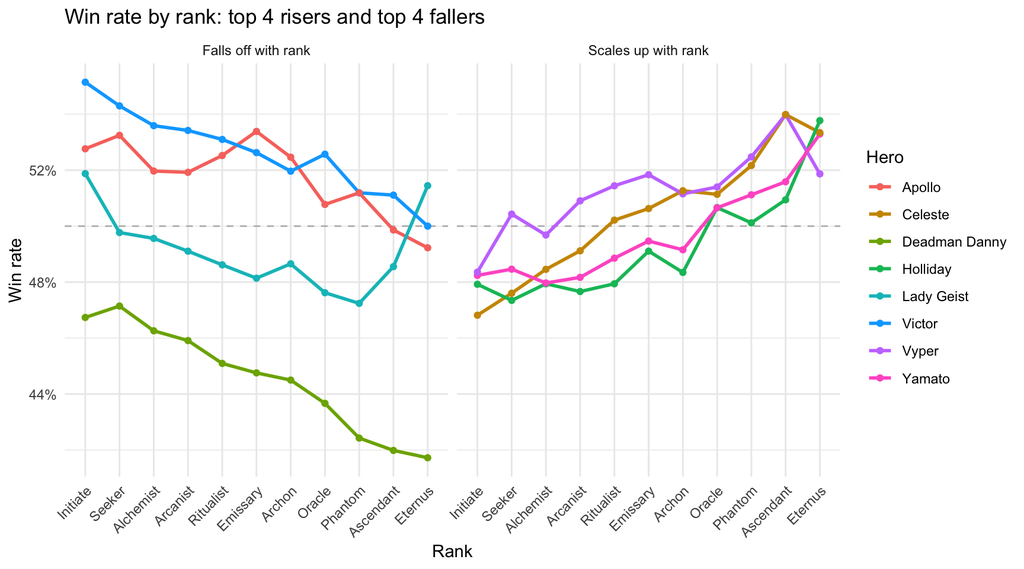

```r
extremes <- bind_rows(slice_max(slopes, slope, n = 4),
                      slice_min(slopes, slope, n = 4)) %>%
  pull(hero_id)

hero_rank %>%
  filter(hero_id %in% extremes) %>%
  left_join(select(slopes, hero_id, trend), by = "hero_id") %>%
  ggplot(aes(rank_name, win_rate, group = hero_name, color = hero_name)) +
  geom_hline(yintercept = 0.5, linetype = "dashed", color = "grey") +
  geom_line(linewidth = 1) + geom_point() +
  facet_wrap(~ trend) +
  scale_y_continuous(labels = scales::percent) +
  labs(title = "Win rate by rank: top 4 risers and top 4 fallers",
       x = "Rank", y = "Win rate", color = "Hero") +
  theme_minimal() +
  theme(axis.text.x = element_text(angle = 45, hjust = 1))
```

### How Play Changes With Rank

The stats file records totals of what players did, so I can ask how the *average match* looks at each rank. I divided each stat by the number of matches to get a per-match average, then plotted that average across the 11 ranks.

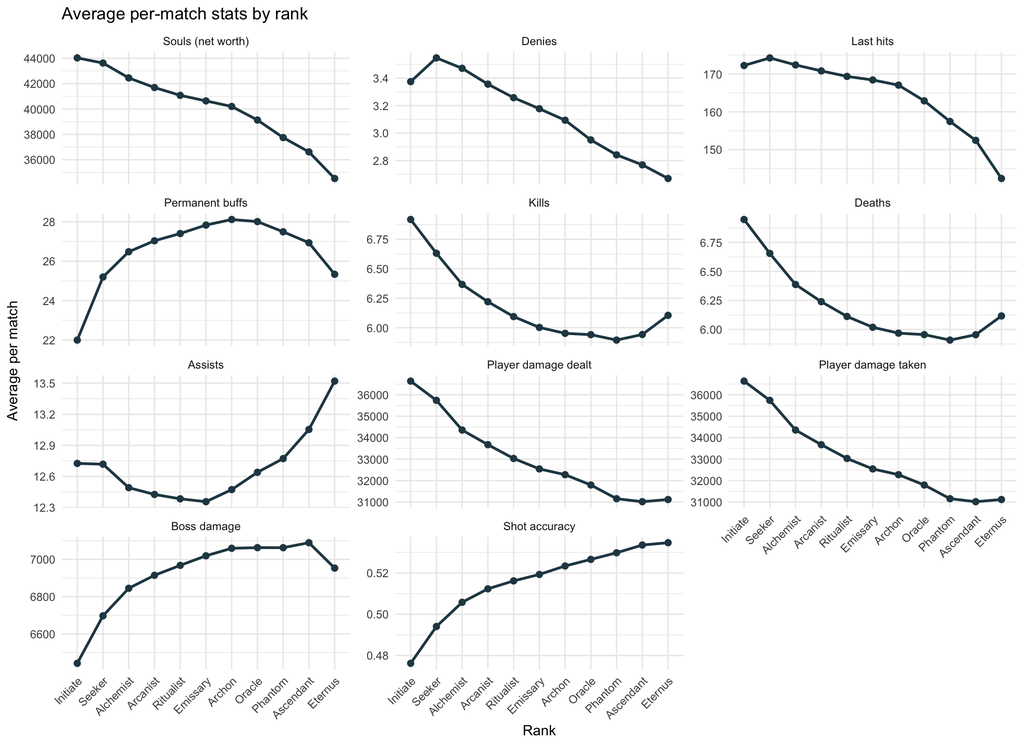

```r
stat_labels <- c(net_worth = "Souls (net worth)", denies = "Denies", last_hits = "Last hits",
                 permanent_buffs = "Permanent buffs", kills = "Kills", deaths = "Deaths",
                 assists = "Assists", damage_dealt = "Player damage dealt",
                 damage_taken = "Player damage taken", boss_damage = "Boss damage",
                 accuracy = "Shot accuracy")

rank_avgs <- hero_rank %>%
  group_by(rank_tier, rank_name) %>%
  summarise(net_worth       = sum(total_net_worth) / sum(matches),
            denies          = sum(total_denies) / sum(matches),
            last_hits       = sum(total_last_hits) / sum(matches),
            permanent_buffs = sum(total_permanent_buffs) / sum(permanent_buff_matches),
            kills           = sum(total_kills) / sum(matches),
            deaths          = sum(total_deaths) / sum(matches),
            assists         = sum(total_assists) / sum(matches),
            damage_dealt    = sum(total_player_damage) / sum(matches),
            damage_taken    = sum(total_player_damage_taken) / sum(matches),
            boss_damage     = sum(total_boss_damage) / sum(matches),
            accuracy        = sum(total_shots_hit) / (sum(total_shots_hit) + sum(total_shots_missed)),
            .groups = "drop") %>%
  pivot_longer(all_of(names(stat_labels)), names_to = "stat", values_to = "value") %>%
  mutate(stat = factor(stat_labels[stat], levels = stat_labels))

ggplot(rank_avgs, aes(rank_name, value, group = 1)) +
  geom_line(linewidth = 1, color = "#264653") +
  geom_point(size = 2, color = "#264653") +
  facet_wrap(~ stat, scales = "free_y", ncol = 3) +
  labs(title = "Average per-match stats by rank",
       x = "Rank", y = "Average per match") +
  theme_minimal() +
  theme(axis.text.x = element_text(angle = 45, hjust = 1))
```

**What this shows.** Players get *cleaner*, not flashier, as they climb:

- **Shot accuracy rises steadily from about 47.6% at Initiate to 53.5% at Eternus**, a direct sign of better aim.
- **Deaths fall from about 6.95 per match at Initiate to about 5.91 at Phantom** (a drop of roughly 15%), which means higher-ranked players make fewer mistakes. Interestingly, deaths rise again to about 6.12 at Eternus, where every opponent is also good.
- **Assists climb at the top** (from a low of about 12.4 at Emissary to 13.5 at Eternus), pointing to more team fighting.
- Surprisingly, **souls (net worth) per match fall, from about 44,000 at Initiate to about 34,500 at Eternus**, and denies and last hits fall too. I do not have match duration in this data, so I cannot prove it, but the most likely explanation is that high-rank matches end sooner, so players have less time to collect souls.

Kills and deaths are almost identical at every rank (for example 6.92 vs 6.95 at Initiate), which is exactly what you would expect since every kill is someone’s death, so this works as a useful sanity check on the data.

### Average deaths per character per rank

For fun: who dies the most, and does every hero die less as ranks go up?

```r
death_order <- hero_rank %>%
  group_by(hero_name) %>%
  summarise(avg_deaths = sum(total_deaths) / sum(matches), .groups = "drop") %>%
  arrange(avg_deaths) %>%
  pull(hero_name)

p <- hero_rank %>%
  mutate(hero_name = factor(hero_name, levels = death_order),
         text = paste0(hero_name, " (", rank_name, ")<br>Deaths/match: ", round(deaths, 1),
                       "<br>Matches: ", matches)) %>%
  ggplot(aes(rank_name, hero_name, fill = deaths, text = text)) +
  geom_tile(color = "white") +
  scale_fill_viridis_c(option = "magma", direction = -1) +
  labs(title = "Average deaths per match, by hero and rank",
       x = "Rank", y = "Hero", fill = "Deaths") +
  theme_minimal() +
  theme(axis.text.x = element_text(angle = 45, hjust = 1))

ggplotly(p, tooltip = "text")
```

[interactive chart not shown]

## Exploratory Data Analysis: Non-Obvious Questions

The graphs above gave a first look. This section asks four questions where the answer is not obvious from the raw numbers, and for each one gives the question, the analysis, the evidence, and the answer.

### Question 1: Does the community ban the heroes that win the most?

**Analysis.** I compared each hero’s ban share with its win rate (the ban scatter plot above) and calculated the correlation across the 38 heroes with ban data. I also compared it to pick rate.

**Evidence.** The correlation between ban share and win rate is only about **0.29**, weaker than the correlation between pick rate and win rate (about 0.46). Haze is the most banned hero (7.6% of bans) with a very ordinary 52.9% win rate. The Doorman is the second most banned (5.8%) with a *below-average* 46.0% win rate and just 1.2% of picks. Meanwhile Graves (55.1% win rate) and Paige (55.0%) win far more but are banned much less (Paige gets only 1.3% of bans). I also checked whether bans change by rank: Haze’s ban share falls from about 8.1% at Initiate to about 6.5% at Eternus, while Wraith’s rises from about 4.5% at Initiate to about 6.3% at Oracle before dipping at Eternus.

**Answer.** No. **Bans reflect how annoying or scary a hero feels, not how much it wins**, and what players fear changes by rank. Haze and The Doorman are likely banned because of their kits (hard to play against), not their results, and strong-but-quiet heroes like Paige go under the radar. This is a good reminder that player opinion and win rate are two different measures.

### Question 2: Is the strongest hero overall also the strongest at the top of the ladder?

**Analysis.** Rat King has the highest overall win rate (55.8%), so I broke its win rate out by rank, and compared the best heroes at ranks Oracle and above (rank tiers 8 to 11) to the overall list.

**Evidence.** Rat King wins between about 55.6% and 56.6% in the first seven ranks, then it drops: **55.0% at Phantom, 54.4% at Ascendant, and just 51.9% at Eternus**, the highest rank. At the high ranks as a group (Oracle and above), it is still the best hero (54.9% win rate) and is picked about 5.8% of the time, but its lead has narrowed sharply. Meanwhile Celeste, with only a 49.7% overall win rate, climbs to over 52% at high ranks.

**Answer.** Rat King is currently the strongest hero, but **its strength fades exactly where the best players are**, which suggests that its power depends partly on opponents who do not know how to play against it. That is a very different story from “Rat King is broken.” Heroes like Celeste, whose results climb with rank, may be better long-term choices for a player who wants to keep improving.

### Question 3: Do the new heroes start weak and improve as players learn them?

**Analysis.** For each of the six new heroes, I counted days since the hero first appeared in the data and grouped them into 4-day windows. I then plotted the win rate in each window.

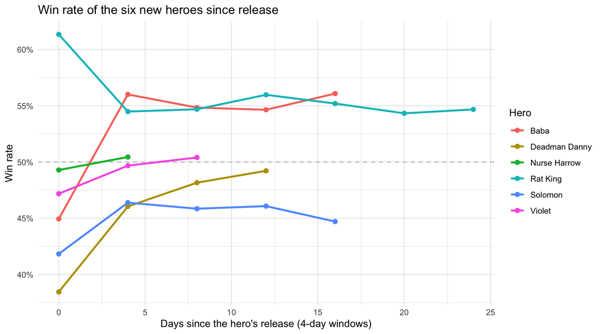

```r
first_seen <- stats %>%
  mutate(date = as_date(as_datetime(bucket))) %>%
  group_by(hero_name) %>%
  summarise(first_date = min(date), .groups = "drop")

new_heroes <- first_seen %>%
  filter(first_date > min(first_date)) %>%    # heroes that appeared after the dataset began
  pull(hero_name)

new_curve <- stats %>%
  mutate(date = as_date(as_datetime(bucket))) %>%
  filter(hero_name %in% new_heroes) %>%
  left_join(first_seen, by = "hero_name") %>%
  mutate(days_since_release = as.numeric(date - first_date),
         window_start = 4 * (days_since_release %/% 4)) %>%
  group_by(hero_name, window_start) %>%
  summarise(matches = sum(matches), win_rate = sum(wins) / sum(matches), .groups = "drop") %>%
  filter(matches >= 5000)                      # drop tiny partial windows

ggplot(new_curve, aes(window_start, win_rate, color = hero_name)) +
  geom_hline(yintercept = 0.5, linetype = "dashed", color = "grey") +
  geom_line(linewidth = 1) + geom_point(size = 2) +
  scale_y_continuous(labels = scales::percent) +
  labs(title = "Win rate of the six new heroes since release",
       x = "Days since the hero's release (4-day windows)",
       y = "Win rate", color = "Hero") +
  theme_minimal()
```

**Answer.** Yes, for most of them. **New heroes have a clear learning curve**: early players are still figuring out how to use them, and win rates improve over a couple of weeks. Rat King is the exception, probably because it is so strong that opponents slowly learn how to counter it (or because Valve adjusted it, which I cannot see in this data). A caution: the same pattern could be partly explained by balance patches during the month, since I only have the data and not the patch notes.

### Question 4: Does the average player get better in every way as rank increases?

**Analysis.** I plotted the per-match average of 11 statistics at each rank (the facet plot above).

**Evidence.** Aim and survival improve (accuracy +5.9 percentage points, deaths down about 15% from Initiate to Phantom), but **souls per match go down by about 22%** (44,000 to 34,500), and denies fall from 3.4 to 2.7 per match. Deaths also tick back up at the very top rank (5.91 at Phantom to 6.12 at Eternus).

**Answer.** Not in every way, and that is the point. Better players are more accurate and die less, but they do not collect more souls per match. The most likely reason is that high-rank matches are shorter, so there is less time to farm, but the data cannot confirm this (match duration is not included). Also, the uptick in deaths at Eternus is a reminder that the top rank’s opponents are also very strong, so relative performance can stay flat even as absolute skill rises.

## Summary

### Major findings and answers to the research questions

- **The meta is not what the ban list suggests.** Haze is the most banned hero (about 7.6% of bans) and The Doorman is second (5.8%), yet The Doorman wins only about 46% of games. Bans reflect frustration and fear, not strength (correlation with win rate about 0.29), while picks follow strength more closely (about 0.46).
- **A brand-new hero ended up on top.** Rat King is the most picked (about 5.7%) and most successful (about 55.8%) hero, despite being released on October 2, after the dataset began. That means the patch changed the meta significantly rather than just adding new options.
- **Hero strength depends on skill level.** Celeste, Holliday, Yamato, Vyper, Mina, and Wraith get stronger as ranks rise, while Deadman Danny, Victor, Lady Geist, Apollo, and Violet get weaker. The differences are real but modest (the biggest movers shift about 4 percentage points, most much less), so skill still matters far more than hero choice.
- **“Best overall” and “best at the top” are not the same thing.** Rat King’s win rate falls from about 56% in most ranks to about 52% at Eternus, which suggests it is strong largely against opponents who have not learned to counter it.
- **New heroes have a learning curve.** Baba and Deadman Danny improved by roughly 10 percentage points within a few weeks of release, which means that a new hero’s first-week win rate is a poor guide to how good it really is.
- **Higher ranks are cleaner, not richer.** Better players aim more accurately (about 47.6% to 53.5%) and die less (about 6.95 to 5.91 per match), but earn fewer souls per match, which most likely points to shorter games at high ranks.
- **Deaths are mostly about the hero you play.** Nurse Harrow, Grey Talon, and Rem die the least (about 5.0 to 5.1 per match), while Bebop, Drifter, and Yamato die the most (about 7.4 to 7.6), and almost everyone improves with rank.

### Possible explanations

- Heroes that fade at high ranks may rely on tricks or surprise that better players learn to answer, while heroes that scale reward positioning, aim, and game knowledge that only come with practice.
- New heroes improve because the community is simultaneously learning builds, strategies, and counters, so early data mixes the hero’s true strength with ignorance about it.
- Bans probably track how a hero *feels* to play against, such as heroes with hard-to-avoid damage or crowd control, which explains why a low-winning hero like The Doorman is banned so often.

### Limitations

- **Aggregated data:** the API only gives totals per hero, rank, and day, so I can compare heroes but not individual players or winners versus losers within a match. Hero-level correlations should not be read as causes.
- **No match length, items, or patch notes:** I can only guess at explanations like shorter matches at high ranks or balance changes during the month.
- **Short and uneven window:** the data covers one month, and the six new heroes had between 6 and 24 days of data, so their pick rates and win rates are not directly comparable to the older heroes.
- **Missing ban data for the new heroes,** so I cannot say how often they were banned.
- **Small samples in some cells:** top-rank hero data is thinner (Eternus has only about 114,000 hero-matches, compared with over 1 million at Seeker), so I required at least 200 matches per cell, but the highest-rank conclusions are still the noisiest.
- **Closed beta:** the game is in active development, so these results describe one snapshot of the meta and may be out of date after the next patch.

### Ideas for future work

- Re-pull the data after the next patch and compare the two metas directly, using patch notes to separate “players learning” from “Valve rebalancing.”
- Add match duration and item data to test whether souls fall at high ranks because games are shorter.
- Model win rate with a regression that includes hero, rank, and days since release together, instead of looking at one factor at a time.
- Compare how each hero’s pick and ban rates move by rank to find heroes that are “feared” only at certain skill levels.
- Track the same heroes over several months to see how long a new hero’s learning curve actually lasts.

### Final conclusions

- **Popularity, fear, and strength are three different things in Deadlock.** The heroes picked most (Rat King, Haze, Infernus), banned most (Haze, The Doorman), and winning most (Rat King, Graves, Paige) only partly overlap, so anyone trying to read the meta from only one of these will be misled.
- **The six new heroes reshaped the meta immediately.** Within weeks, Rat King had become both the most picked and most successful hero, which shows how much influence a single patch can have on a competitive game, and it makes the case for Valve watching hero data day by day instead of waiting for complaints.
- **Early win rates of a new hero should be taken with a grain of salt.** Most of the new heroes improved within two weeks, so an analyst or a balance team that judged them on their first few days would have been wrong about most of them.
- **Skill expression is real but small.** The heroes that scale with rank and those that fade differ by a few percentage points at most, so for most players, improving aim and survival will matter much more than choosing the “right” hero.
- **If you want to climb, choose scaling heroes.** Celeste, Holliday, Yamato, Vyper, Mina, and Wraith keep getting better at higher ranks, while heroes like Deadman Danny and Rat King may get harder to win with as opponents get smarter.
- **Skill shows up as discipline, not as farming.** High-rank players die less and shoot more accurately but collect fewer souls, which suggests that in this game, winning at the top is about efficiency, positioning, and fights, not about getting rich the fastest.
- **The data answers “what,” but not always “why.”** Many of the most interesting explanations (match length, patch changes, why The Doorman is banned) are hypotheses I could not test with aggregated data, which is the biggest reason I would want richer data for a follow-up project.
- **Overall takeaway:** Deadlock’s community behaves the way people in any competitive game do: loud opinions, fast learning, and a meta that changes faster than anyone’s intuition. Looking at the numbers rather than the vibes is a good way to tell which opinions hold up.